# Homework 3

### Q1: What can you say about the preferences of sender men and women related to the looks of the receiver? Are there differences across the genders?

The probability that a man sends a message based on the look of the other person is more than women. This means that the look of the people you want to contact is more important for men.

### Q2: Does the utility/preference function change depending on the looks of the Sender? Are there differences in how these changes for men and women?

As the following graph shows intersting conclusions for the utility function dependending of the Looks of the sender: In the first row, the graph shows the probabilities of man and women where their looks are “less than average” (<6) and the probability to send a message for depending on the looks of their reciever.

The probability of a man that its look is less than average will diminish if the reciever is very good looking (>8) The probability of a women that its look is less than average will increase if the reciever is not so good looking (they have more confidence), but will decrease if the reciever is very good looking.

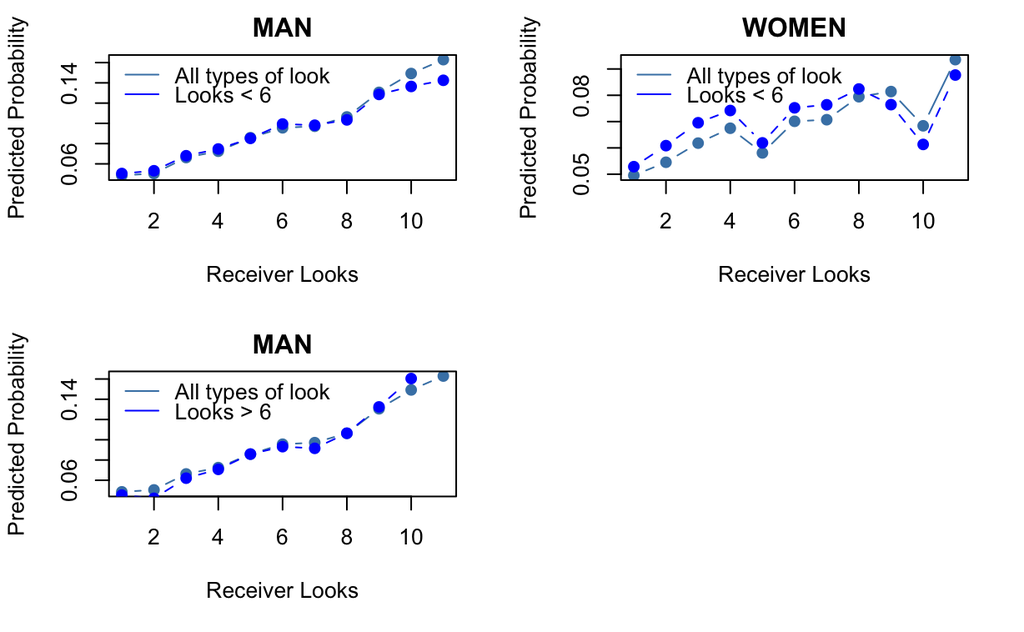

### Q3: Using the pred.match function explore the match scores between men and women at various looks percentiles. Comment on and explain your findings. For example, you may want to explore why pred.match(2,10) differs from pred.match(10,2).

In the following plot we can see how the match propensity by the different looks of men and women. As you can see, matching score arises when looks are higher.

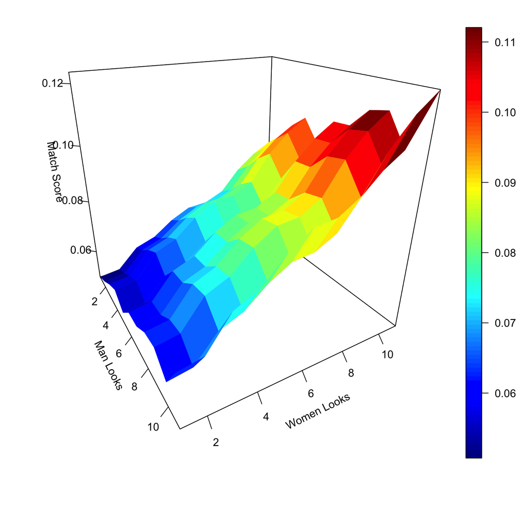

# Q4: (Optional: Warning Difficult and Time Consuming!)

# How would you change the match function to account

# for the findings in Q2. How do the results compare to

# the original pred.match function results.